# World Happiness Report from year 2005-2021

Kristen Blessman-Garcia

2023-04-27

## Introduction

The data is a CSV from Kaggle based on the Gallup World Poll/World Happiness Reports from 2005-2021. It shows the national average response to a question of subjective well being.

- A link to the data [World Happiness Report 2005-2021](https://www.kaggle.com/datasets/jahaidulislam/world-happiness-report-2005-2021)

## Problem Statement and Questions

- To understand global happiness trends and the factors contributing to well-being.
  - Which countries were in the top ten most frequently?
  - Which countries had the lowest happiness score most frequently?
  - How do the continents compare on their happiness score?
  - Which factors are related to an increased score on the happiness report?

## Background/Why?

I have practiced as an occupational therapy assistant for the past ten years and have an interest in the social/emotional well being of my clients. Also, my domain focus for data science is psychology so I wanted a relevant dataset.

## World Happiness Report is measured in Life.Ladder

Please imagine a ladder, with steps numbered from 10 at the top to 0 at the bottom.

## Ten

- The top of the ladder represents the best possible life for you.
- The bottom of the ladder represents the worst possible life for you.

## Zero

## What Libraries did you use?

- library(tidyverse) #Use to tidy and filter the data with dplyr
- library(ggplot2) #Use to draw plots
- library(countrycode) #Use to categorize countries by continent

## Let’s take a look at the unfiltered data

```
## Rows: 2,089
## Columns: 12
## $ Country.Name                      <chr> "Afghanistan", "Afghanistan", "Afgha…
## $ Year                              <int> 2008, 2009, 2010, 2011, 2012, 2013, …
## $ Life.Ladder                       <dbl> 3.723590, 4.401778, 4.758381, 3.8317…
## $ Log.GDP.per.capita                <dbl> 7.302574, 7.472446, 7.579183, 7.5520…
## $ Social.support                    <dbl> 0.4506623, 0.5523084, 0.5390752, 0.5…
## $ Healthy.life.expectancy.at.birth  <dbl> 50.500, 50.800, 51.100, 51.400, 51.7…
## $ Freedom.to.make.life.choices      <dbl> 0.7181143, 0.6788964, 0.6001272, 0.4…
## $ Generosity                        <dbl> 0.173169285, 0.195469126, 0.12585946…
## $ Perceptions.of.corruption         <dbl> 0.8816863, 0.8500354, 0.7067661, 0.7…
## $ Positive.affect                   <dbl> 0.4142970, 0.4814214, 0.5169067, 0.4…
## $ Negative.affect                   <dbl> 0.2581955, 0.2370924, 0.2753238, 0.2…
## $ Confidence.in.national.government <dbl> 0.6120721, 0.6115452, 0.2993574, 0.3…
```

- On the next slide I’ll provide some definitions.
- Due to the length of the presentation and multiple columns, I will only explore the columns of: Confidence in national government, perceptions of corruption, life expectancy, GDP, social support and freedom to make life choices.

## Data Key Terms and Columns we will look at today:

- GDP per capita- (variable name gdp) Gross Domestic Product
- Healthy life expectancies at birth are based on the data extracted from the World Health Organization’s (WHO) Global Health Observatory data repository

Binary Responses:

- Perception of corruption- “Is corruption widespread within businesses/ government or not?”
- Confidence in the national government- “Do you have confidence in your national government?”
- Social support- “If you were in trouble, do you have relatives or friends you can count on to help you?”
- Freedom to make life choices- “Are you satisfied with your freedom to choose what you do with your life?”

## Missing Data

- Compared to the large dataset of 2089 rows, the amount of missing values were negligible.

```r
sapply(data1, function(x) sum(is.na(x)))
```

```
##                      Country.Name                              Year
##                                 0                                 0
##                       Life.Ladder                Log.GDP.per.capita
##                                 0                                27
##                    Social.support  Healthy.life.expectancy.at.birth
##                                13                                58
##      Freedom.to.make.life.choices                        Generosity
##                                32                                80
##         Perceptions.of.corruption                   Positive.affect
##                               113                                24
##                   Negative.affect Confidence.in.national.government
##                                16                               216
```

- I used na.omit() to remove the missing values.

## Let’s Filter the data to a particular year and find the countries with the max happiness score

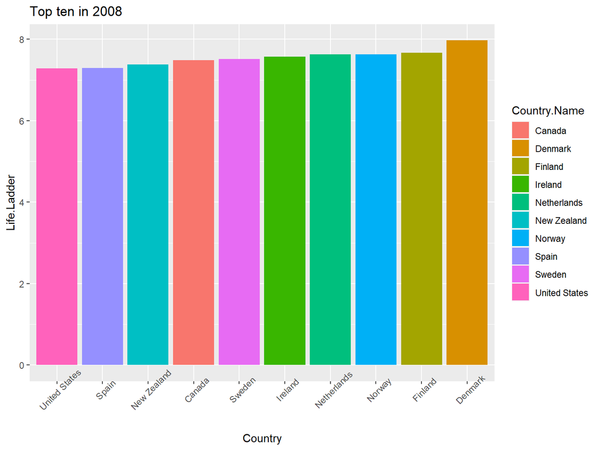

- This plot is interesting, however it only shows the results from one year. Let’s filter the data again to look at the max encompassing all of the years.

## The countries with the highest happiness scores most frequently

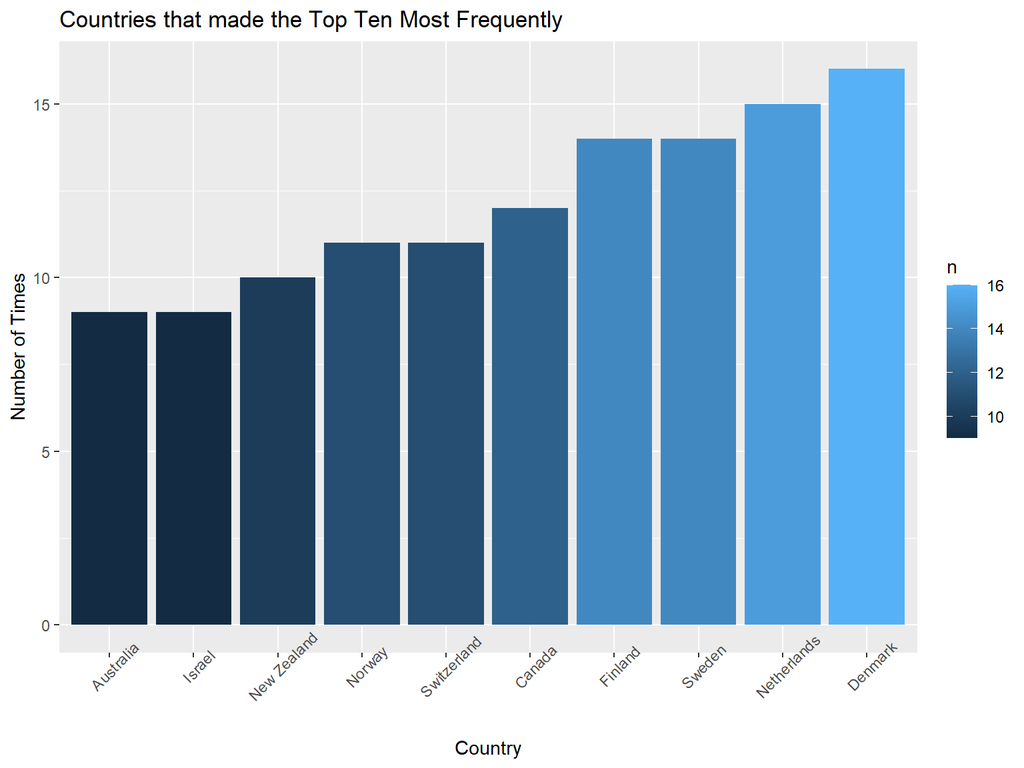

## The countries with the lowest happiness scores most frequently

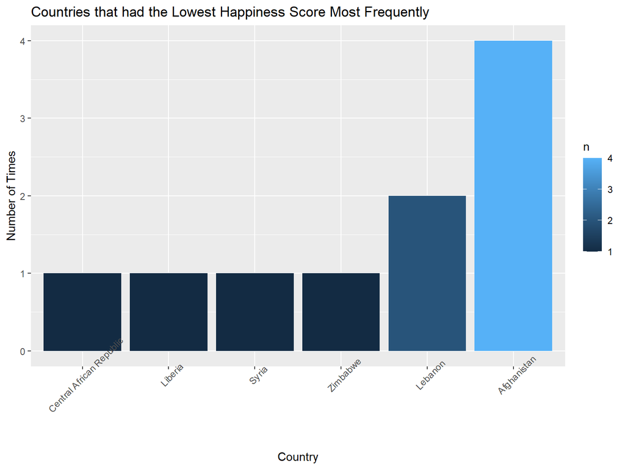

- Next, Let’s start exploring some factors that might influence the happiness score.
- Let’s see if there is a relationship between having confidence in the national government and overall well-being.

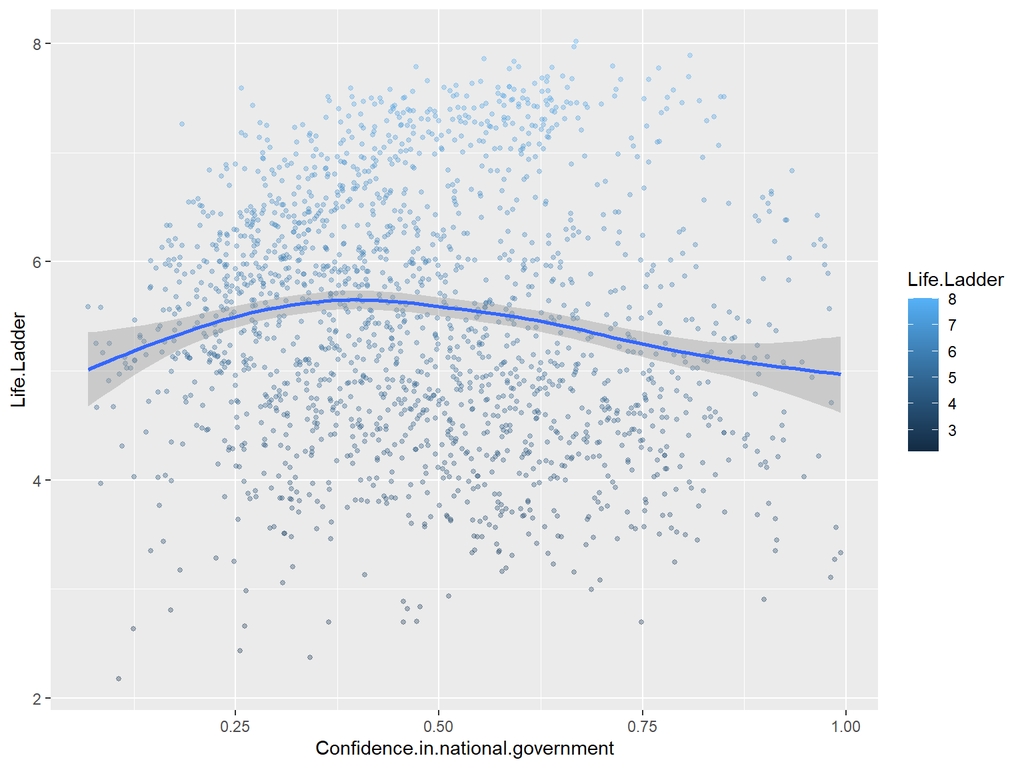

- This chart is overplotted and it is difficult to see a clear relationship.
- Let’s filter the data to different years to see if a relationship emerges.

## Here is a facet_wrap plot showing the relationship between confidence in the Govt and happiness score on 5 year intervals

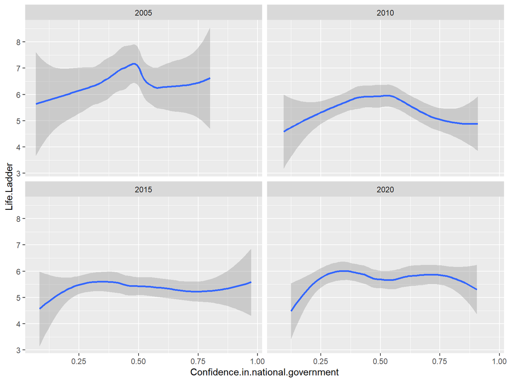

- Next up is the perception of corruption.

## Bolivia & USA

- I have heard that there is a high perception of corruption in Bolivia. I wanted to explore the relationship with a plot.

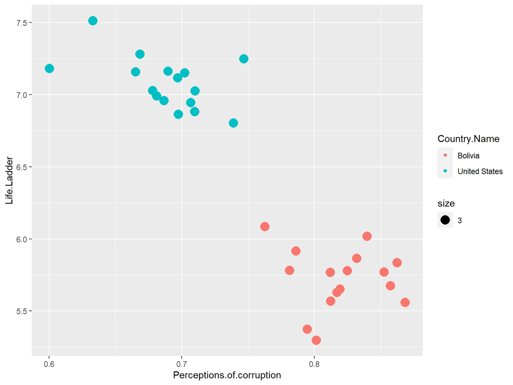

- Next we will look at life expectancy.

## Does healthy Life Expectancy have a relationship with Well-Being?

- Let’s explore a violin plot between Kenya, India, Mexico, and Finland.

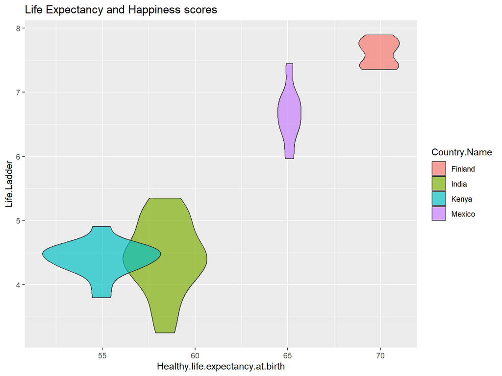

-Next, let’s use the countrycode library to take a look at happiness in each continent.

# The original dataset did not have a category for continent, however RStudio has a library called countrycode which can be used to categorize by continent.

- It uses the five continent model:
- a dataframe showing the Life.Ladder for each continent
  - average
  - max
  - min

```
## # A tibble: 5 × 4
##   Continent   avg   max   min
##   <chr>     <dbl> <dbl> <dbl>
## 1 Africa     4.39  6.35  2.69
## 2 Americas   6.10  7.65  3.35
## 3 Asia       5.29  7.58  2.18
## 4 Europe     6.18  8.02  3.84
## 5 Oceania    7.28  7.60  7.11
```

- Something doesn’t look right with Oceania, let’s take a closer look on the next slide.

## Because of the closeness in Oceania’s numbers, let’s take a closer look at Oceania to see which countries it represents in this dataset.

```r
Oceania =data1 %>% filter(Continent == 'Oceania') %>% count(Country.Name)
Oceania
```

```
##   Country.Name  n
## 1    Australia 15
## 2  New Zealand 15
```

- Now we know it only represents two countries. The 15 represents the number of years.

## Average happiness score by Continent

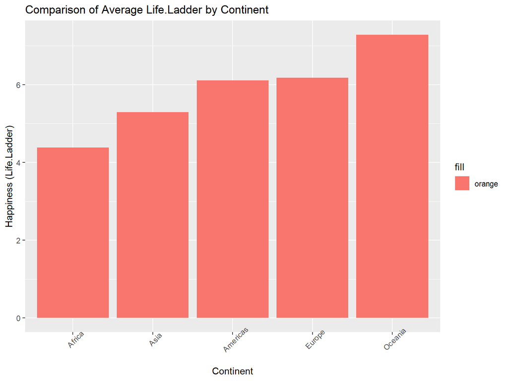

[figure not shown]

- According to the data, happiness generally increases with GDP.

# This dataframe shows the relationship between social support and the feeling of well-being.

- Social support- “If you were in trouble, do you have relatives or friends you can count on to help you?”

```
## # A tibble: 5 × 3
##   Continent avg_social_support median_life_ladder
##   <chr>                  <dbl>              <dbl>
## 1 Africa                 0.709               4.37
## 2 Asia                   0.772               5.10
## 3 Americas               0.856               6.12
## 4 Europe                 0.896               6.16
## 5 Oceania                0.948               7.26
```

## A box plot of each Continent showing social support on the x-axis and life ladder on the y-axis

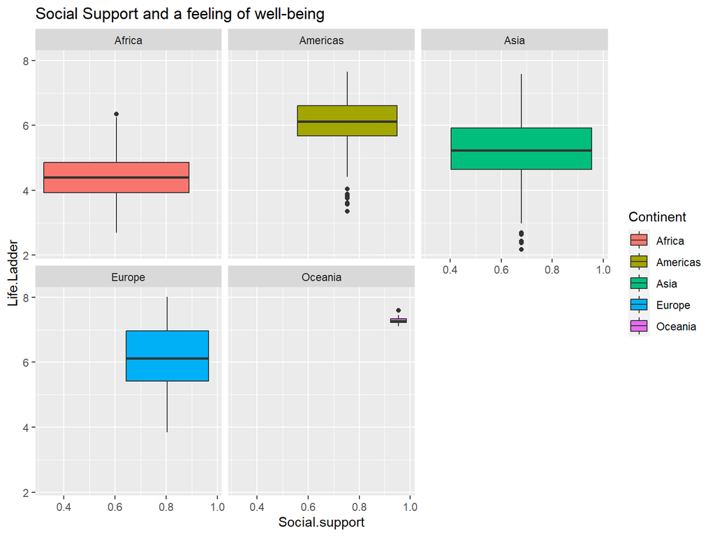

Let’s explore one more category: Freedom to make life choices.

- Freedom to make life choices- “Are you satisfied with your freedom to choose what you do with your life?”

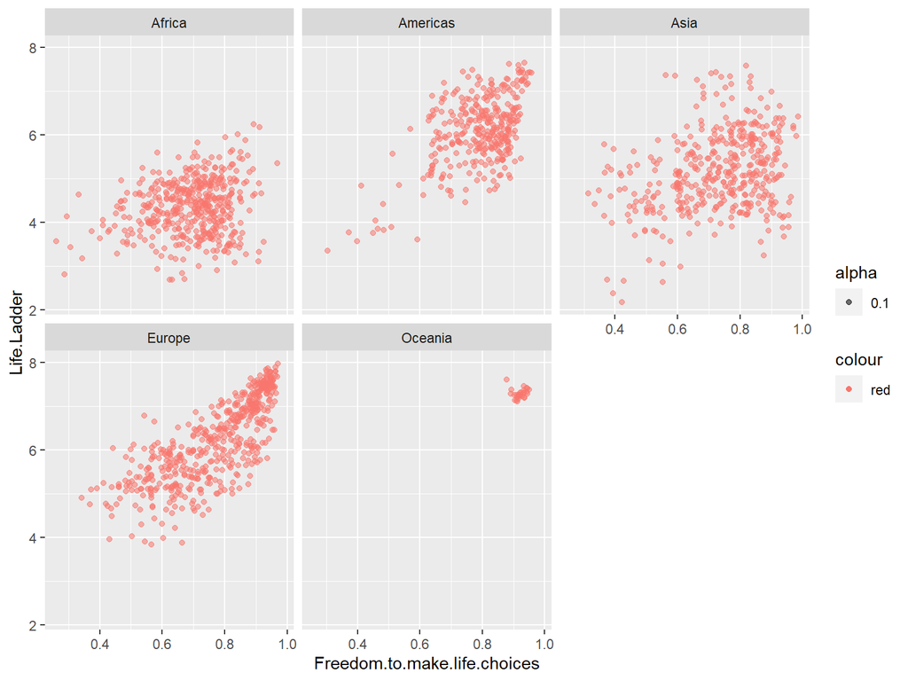

## Summary

[output not shown]